# Data605 - Assignment11

Kishore Prasad

Nov 6, 2016

## Problem set 1

Using R’s lm function, perform regression analysis and measure the significance of the independent variables for the following two data sets. In the first case, you are evaluating the statement that we hear that Maximum Heart Rate of a person is related to their age by the following equation:

MaxHR = 220 - Age

You have been given the following sample:

Age 18 23 25 35 65 54 34 56 72 19 23 42 18 39 37

MaxHR 202 186 187 180 156 169 174 172 153 199 193 174 198 183 178

Perform a linear regression analysis fitting the Max Heart Rate to Age using the lm function in R. What is the resulting equation? Is the effect of Age on Max HR significant? What is the significance level? Please also plot the fitted relationship between Max HR and Age.

**Answer:**

```r
library(ggplot2)
library(knitr)

Age <- c(18, 23, 25, 35, 65, 54, 34, 56, 72, 19, 23, 42, 18, 39, 37)
MaxHR <- c(202, 186, 187, 180, 156, 169, 174, 172, 153, 199, 193, 174, 198, 183, 178)

data <- data.frame(Age, MaxHR)

output <- summary(lm(MaxHR ~ Age, data=data))

output
```

```
##
## Call:
## lm(formula = MaxHR ~ Age, data = data)
##
## Residuals:
##     Min      1Q  Median      3Q     Max
## -8.9258 -2.5383  0.3879  3.1867  6.6242
##
## Coefficients:
##              Estimate Std. Error t value Pr(>|t|)
## (Intercept) 210.04846    2.86694   73.27  < 2e-16 ***
## Age          -0.79773    0.06996  -11.40 3.85e-08 ***
## ---
## Signif. codes:  0 '***' 0.001 '**' 0.01 '*' 0.05 '.' 0.1 ' ' 1
##
## Residual standard error: 4.578 on 13 degrees of freedom
## Multiple R-squared:  0.9091, Adjusted R-squared:  0.9021
## F-statistic:   130 on 1 and 13 DF,  p-value: 3.848e-08
```

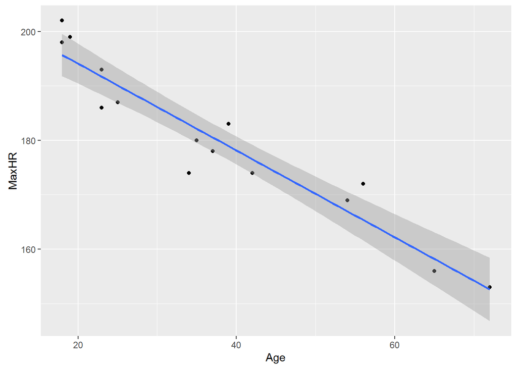

```r
ggplot(data, aes(x=Age, y=MaxHR)) +
  geom_point() +
  stat_smooth(method=lm)
```

## Problem set 2

Using the Auto data set from Assignment 5 (also attached here) perform a Linear Regression analysis using mpg as the dependent variable and the other 4 (displacement, horse-power, weight, acceleration) as independent variables. What is the final linear regression fit equation? Which of the 4 independent variables have a significant impact on mpg? What are their corresponding significance levels? What are the standard errors on each of the coefficients? Please perform this experiment in two ways. First take any random 40 data points from the entire auto data sample and perform the linear regression fit and measure the 95% confidence intervals. Then, take the entire data set (all 392 points) and perform linear regression and measure the 95% confidence intervals. Please report the resulting fit equation, their significance values and confidence intervals for each of the two runs.

#### Part 1 - Using Full dataset

```r
# Assuming that the data file is located in the working directory.

data <- read.table('auto-mpg.data', col.names=c('displacement', 'horsepower', 'weight', 'acceleration', 'mpg'))
head(data)
```

```
##   displacement horsepower weight acceleration mpg
## 1          307        130   3504         12.0  18
## 2          350        165   3693         11.5  15
## 3          318        150   3436         11.0  18
## 4          304        150   3433         12.0  16
## 5          302        140   3449         10.5  17
## 6          429        198   4341         10.0  15
```

```r
model <- lm(mpg ~ displacement + horsepower + weight + acceleration, data=data)
model
```

```
##
## Call:
## lm(formula = mpg ~ displacement + horsepower + weight + acceleration,
##     data = data)
##
## Coefficients:
##  (Intercept)  displacement    horsepower        weight  acceleration
##    45.251140     -0.006001     -0.043608     -0.005281     -0.023148
```

```r
output <- summary(model)
output
```

```
##
## Call:
## lm(formula = mpg ~ displacement + horsepower + weight + acceleration,
##     data = data)
##
## Residuals:
##     Min      1Q  Median      3Q     Max
## -11.378  -2.793  -0.333   2.193  16.256
##
## Coefficients:
##                Estimate Std. Error t value Pr(>|t|)
## (Intercept)  45.2511397  2.4560447  18.424  < 2e-16 ***
## displacement -0.0060009  0.0067093  -0.894  0.37166
## horsepower   -0.0436077  0.0165735  -2.631  0.00885 **
## weight       -0.0052805  0.0008109  -6.512  2.3e-10 ***
## acceleration -0.0231480  0.1256012  -0.184  0.85388
## ---
## Signif. codes:  0 '***' 0.001 '**' 0.01 '*' 0.05 '.' 0.1 ' ' 1
##
## Residual standard error: 4.247 on 387 degrees of freedom
## Multiple R-squared:  0.707,  Adjusted R-squared:  0.704
## F-statistic: 233.4 on 4 and 387 DF,  p-value: < 2.2e-16
```

**Answer:**

The fit equation is given by the following equation:

$mpg = 45.2511397 + (-0.0060009 * displacement) + (-0.0436077 * horsepower) + (-0.0052805 * weight) + (-0.023148 * acceleration)$

The following table displays the significant variables along with the significance level, standard errors and 95% confidence interval for each of the significant variables:

```r
vars <- c('weight', 'horsepower')
significance <- c(output$coefficients[19], output$coefficients[18])
std.err <- c(output$coefficients[9], output$coefficients[8])
confInt_95 <-  rbind(confint(model, 'weight', level=0.95)[1,], confint(model, 'horsepower', level=0.95)[1,])

sig_vars <- cbind(vars, significance, std.err, confInt_95)
kable(sig_vars)
```

| vars | significance | std.err | 2.5 % | 97.5 % |
| --- | --- | --- | --- | --- |
| weight | 2.30254500904123e-10 | 0.000810854064715866 | -0.00687473833229139 | -0.00368627726298031 |
| horsepower | 0.00884898214778294 | 0.0165734633025219 | -0.0761930287979641 | -0.0110224329740852 |

```r
# Assuming that the data file is located in the working directory.

data <- read.table('auto-mpg.data', col.names=c('displacement', 'horsepower', 'weight', 'acceleration', 'mpg'))

set.seed(5)
sample_data <- data[sample(1:length(data$displacement), 40, replace=F),]

model <- lm(mpg ~ displacement + horsepower + weight + acceleration, data=sample_data)
model
```

```
##
## Call:
## lm(formula = mpg ~ displacement + horsepower + weight + acceleration,
##     data = sample_data)
##
## Coefficients:
##  (Intercept)  displacement    horsepower        weight  acceleration
##    45.179413     -0.017265     -0.069612     -0.002715     -0.236157
```

```r
output <- summary(model)
output
```

```
##
## Call:
## lm(formula = mpg ~ displacement + horsepower + weight + acceleration,
##     data = sample_data)
##
## Residuals:
##      Min       1Q   Median       3Q      Max
## -10.7514  -2.6554  -0.6708   2.3013   8.4057
##
## Coefficients:
##               Estimate Std. Error t value Pr(>|t|)
## (Intercept)  45.179413   9.374236   4.820 2.76e-05 ***
## displacement -0.017265   0.023601  -0.732    0.469
## horsepower   -0.069612   0.086637  -0.803    0.427
## weight       -0.002715   0.003834  -0.708    0.484
## acceleration -0.236157   0.544784  -0.433    0.667
## ---
## Signif. codes:  0 '***' 0.001 '**' 0.01 '*' 0.05 '.' 0.1 ' ' 1
##
## Residual standard error: 4.362 on 35 degrees of freedom
## Multiple R-squared:  0.672,  Adjusted R-squared:  0.6345
## F-statistic: 17.93 on 4 and 35 DF,  p-value: 4.307e-08
```

**Answer:**

The fit equation is given by the following equation:

$mpg = 45.1794134 + (-0.0172649 * displacement) + (-0.0696125 * horsepower) + (-0.0027148 * weight) + (-0.2361571 * acceleration)$

In this run (with a small sample), we find that there are no significant variables.